# Predictors of Diversity Outbred Cholesterol Levels

### 7.1.1 Non-Linear Analysis of Cholsterol-Calcium

```r
#nonlinear quadratic
chol.ca.poly <- lm(chol2 ~ calcium2 + I(calcium2^2) + sex + diet, data = cholesterol.data)

#flexible splines
library(splines)
chol.ca.spline <- lm(chol2 ~ ns(calcium2, df = 4) + sex + diet, data = cholesterol.data)

#generalized additive model
library(mgcv)
chol.ca.gam <- gam(chol2 ~ s(calcium2) + sex + diet, data = cholesterol.data)

#comparing models
AIC(chol.ca.lm, chol.ca.poly, chol.ca.spline, chol.ca.gam) |> kable(caption="AIC for nonlinear model fits")
```

AIC for nonlinear model fits

|  | df | AIC |
| --- | --- | --- |
| chol.ca.lm | 5 | 7086 |
| chol.ca.poly | 6 | 7086 |
| chol.ca.spline | 8 | 7089 |
| chol.ca.gam | 5 | 7086 |

```r
#summary(chol.ca.gam)  # look at edf for s(calcium2)
```

This suggests that the models all perform similarly (higher AIC is bad), in this case its probably best to stick with the linear model. The linear model is easier to interpret and understand, and is likely sufficient for this analysis.

## 7.2 Bayesian Approach to Understanding Calcium-Cholesterol Relationship

We employed a Bayesian approach to understanding the calcium-cholesterol relationship because it enables a continuous probability interpretation of the hypotheses under investigation, facilitates the incorporation of prior knowledge when available, and provides a direct and transparent quantification of uncertainty. Bayesian methods also offer substantial flexibility for modeling complex relationships and adjusting for confounding variables. This framework supports more intuitive and informative inferences regarding associations and potential causal effects, particularly when accounting for multiple confounders or integrating prior data.

Our **goal** is to understand, in mice, the relationship between calcium and cholesterol, since it was nominated by our rergression tree approach. We are **modeling** this in the form of a linear regression with sex and diet of the mice as non-interacting covariates.

```r
# Load required packages
library(brms)
library(dplyr)

# Define informative priors (adjust based on your epidemiological context)
priors <- c(
  # Prior for intercept - adjust mean/sd based on domain knowledge
  prior(normal(80, 10), class = "Intercept"),

  # Priors for your covariates - adjusted to mak them slightly less informative
  prior(normal(30, 45), class = "b", coef = "diethf"),
  prior(normal(10, 30), class = "b", coef = "sexM"),
  prior(normal(0, 30), class = "b", coef = "calcium2")
)
```

```r
# For sampling priors
chol.ca.brms.priors <- brm(
  chol2 ~ calcium2 + sex + diet,
  data = cholesterol.data,
  family = student(), # fits to the more robust t-distribution, based on posterior checks
  prior = priors,
  sample_prior = "only",
  chains = 4,
  iter = 2000
)

# Fit the Bayesian linear regression model
chol.ca.brms <- brm(
  formula = chol2 ~ calcium2 + sex + diet,
  data = cholesterol.data,
  family = student(),  # fits to the more robust t-distribution, based on posterior checks
  prior = priors,
  sample_prior = TRUE,  # For prior predictive checks
  chains = 4,
  iter = 4000,
  warmup = 1000,
  cores = 4,
  control = list(adapt_delta = 0.95) # Helps prevent divergent transitions
)
```

#### 7.2.0.1 Prior Predictive Checks

```r
prior_summary(chol.ca.brms) |>
  kable(caption="Summary of priors information provided to brms")
```

Summary of priors information provided to brms

| prior | class | coef | group | resp | dpar | nlpar | lb | ub | tag | source |
| --- | --- | --- | --- | --- | --- | --- | --- | --- | --- | --- |
|  | b |  |  |  |  |  |  |  |  | default |
| normal(0, 30) | b | calcium2 |  |  |  |  |  |  |  | user |
| normal(30, 45) | b | diethf |  |  |  |  |  |  |  | user |
| normal(10, 30) | b | sexM |  |  |  |  |  |  |  | user |
| normal(80, 10) | Intercept |  |  |  |  |  |  |  |  | user |
| gamma(2, 0.1) | nu |  |  |  |  |  | 1 |  |  | default |
| student_t(3, 0, 31.9) | sigma |  |  |  |  |  | 0 |  |  | default |

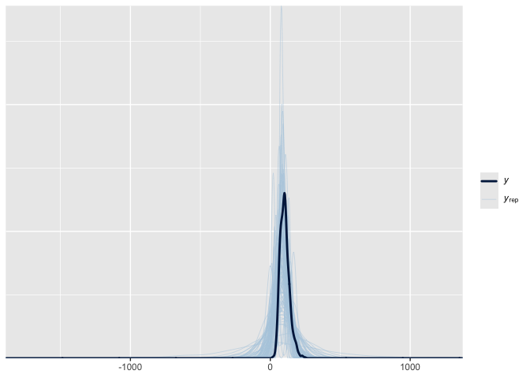

```r
pp_check(chol.ca.brms.priors, type = "dens_overlay", ndraws = 100)
```

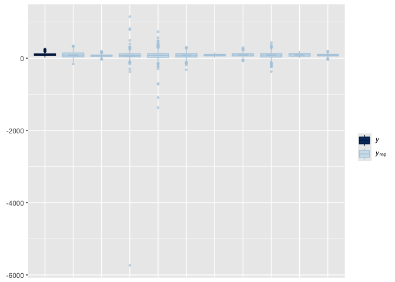

```r
pp_check(chol.ca.brms.priors, type = "boxplot", group = "diet")
```

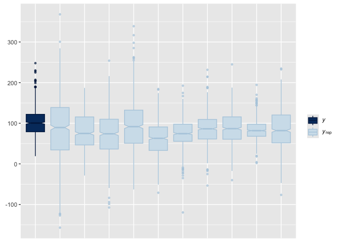

```r
pp_check(chol.ca.brms.priors, type = "boxplot", group = "sex")
```